# P01_2102332J_ASSIGNMENT2

[figure not shown]

## Data Structures and Algorithms (CIT1C14)(CCE1C01)

## Assignment 2 (30%)

### Fill in your personal data below

### Name: Carolyn Mohanty

### Admin No: 2102332J

### Class: P01

## Declaration of Originarity

### I declare that I am the originator of this work and that all other original sources used in this work have been appropriately acknowledged.

### I understand that plagiarism is the act of taking and using the whole or any part of another person’s work and presenting it as my own without proper acknowledgement.

### I understand that allowing someone else to copy my work and submit it as their own is also considered as plagiarism.

### I also understand that plagiarism is an academic offence and that disciplinary action will be taken for plagiarism.”

### Please sign your name or insert a picture of your signature in the markdown cell below. (double click on the cell)

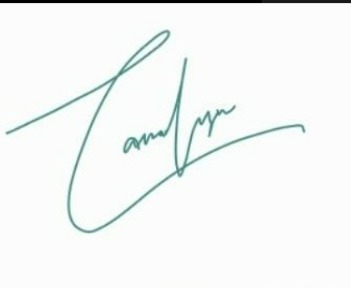

### -------- Warning Warning Warning Warning Warning Warning Warning Warning Warning ---------

## Do not post any assignment questions to stackoverflow, reddit or any other websites for help. If you are caught doing so, disciplinary action will be taken against you.

### 1. This assignment is worth 30% of the final marks for DSAG. The total marks for this assignment is 50 marks. The due date is 6 February 2021 09:00 am.

### 2. This assignment is an individual assignment. You are required to produce your own work.

### 3. Do not create python classes for this project

### 4. You are not allowed to use packages (libraries) not covered in the subject (e.g numpy, pandas, re etc.)

### 5. Provide sufficient comments to your code. Code with less lines and good efficiency will generally be awarded with more marks.

### 6. Name your notebook according to the following format.

> If you are from P01 and your student ID is 2120202A, then rename the Assignment 2 notebook to **P01_2120202A**

### 7. You need to submit your Assignment 2 jupyter notebook in two different formats (ipynb and pdf).

> 1. pdf format is for plagiarism check
> 2. ipynb format is for marking

[figure not shown]

### 8. Post all queries on assignment to [discussion forum in LMS](https://lms.tp.edu.sg/webapps/discussionboard/do/conference?toggle_mode=edit&action=list_forums&course_id=_23703_1&nav=discussion_board_entry&mode=cpview)

[figure not shown]

# Question 1 (20 marks)

### 1. Go LMS-->Assignment 2-->Quiz file for Q1. Download the quiz.csv file and read the file into python.

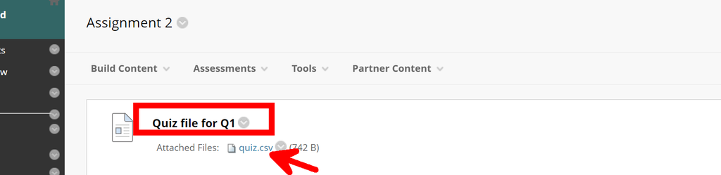

### 2. Create a quiz program using all the questions and answers given in the quiz.csv file

### 3. Show the correct answers when user selected a wrong option

### 4. Randomly choose a congratulatory phrase from Good job! Awesome!, Correct! when user selected a correct option

### 5. At the end of the quiz, show the score

### The given quiz.csv file has the following characteristics

1. It contains many quiz questions and answers.
2. Each question has four options (four possible answers). The first answer immediately after the question is the correct answer. See illustration below:

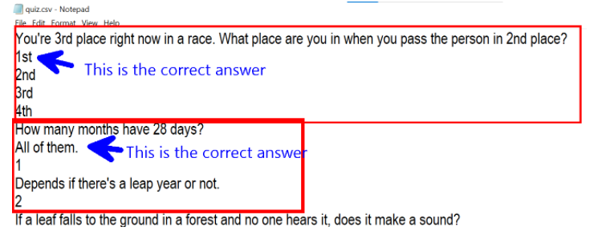

3. You may assume the quiz.csv file will always have a question followed by 4 answers and the first answer is the correct answer.
4. However you should not assume and hardcode the total number of questions in your code. The marker may use different quiz.csv (which contains different number of questions) in marking your program.

### Randomize the questions and randomize the answer choices

1. You should **not** follow the question sequence given in the quiz.csv file
2. You should **not** follow the answer sequence given in the quiz.csv file
3. You should randomize both the questions and the options

### Click here for a demo. [Demo](https://studenttpedu-my.sharepoint.com/:v:/g/personal/kokyau_tp_edu_sg/EdlKZbA5WrVFrTXcJWX4U0kBRUvIuJ_1zM5rZ02os_66kg?e=WKEyby) In the demo, the program was executed 3 times. Notice the randomizing of questions and answers.

```python
import random

# define a function which returns random praise words when the user answers correctly.
def praise ():
    praise_words = ["Good job!", "Awesome!", "Correct!"] #list of praise words
    chosen_word_idx = random.randint(0,2)
    #random int between 0 and 2
    #chosen_word_idx is the index of praise_words
    print (praise_words[chosen_word_idx])

def correct_ans_letter ():
    oA = quiz_contents[options_order[0]]
    oB = quiz_contents[options_order[1]]
    oC = quiz_contents[options_order[2]]
    oD = quiz_contents[options_order[3]]
    if quiz_contents[o1_idx] in oA:
        output = "a,"
    elif quiz_contents[o1_idx] in oB:
        output  = "b,"
    elif quiz_contents[o1_idx] in oC:
        output  = "c,"
    elif quiz_contents[o1_idx] in oD:
        output  = "d,"
    return (output)

# read the csv file and store both the questions and answers in a list
quiz_contents = [] #empty list
with open("quiz.csv") as quiz_file:
    for line in quiz_file:
        line = line.rstrip("\n") #remove all line breaks
        quiz_contents.append(line) #append each line to quiz contents, so the list contains everything in the csv


# generate a random list of question numbers
total_questions = int(len(quiz_contents)/ 5) #number of questions
questions_order = []
for i in range(total_questions): #6
    question_no = random.randint(1,total_questions) #(1,6)
    while question_no in questions_order:
        question_no = random.randint(1,total_questions)
    questions_order.append(question_no)

# keep track of the user's score
user_score = 0

# print question and options in the order in questions order list and collect user input
for n in questions_order:#n is in reference to the question number

    # print the question
    q_idx = 5 * n - 5
    print (quiz_contents[q_idx])

    # generate a random list of options
    o1_idx = 5 * n - 4
    o4_idx = 5 * n - 1
    options_order = []
    for i in range(4):
        option_no = random.randint(o1_idx, o4_idx)
        while option_no in options_order:
            option_no = random.randint(o1_idx, o4_idx) #randomise the option order
        options_order.append(option_no)

    # print the options in the order in the options order list
    print('a.', quiz_contents[options_order[0]])
    print('b.', quiz_contents[options_order[1]])
    print('c.', quiz_contents[options_order[2]])
    print('d.', quiz_contents[options_order[3]])
    print (" ")

    # ask the user to give her or her answer
    user_answer = input("")

    # check whether the user's answer is the correct answer, which is always option 1 in the original list
    # if correct, praise the user and if wrong, print the correct answer
    if user_answer == "a":
        if o1_idx == options_order[0]:
            praise()
            user_score += 1
        else:
            letter = correct_ans_letter ()
            print ("That's incorrect. The correct answer is", letter, quiz_contents[o1_idx] + ".")
    elif user_answer ==  "b":
        if o1_idx ==  options_order[1]:
            praise()
            user_score += 1
        else:
            letter = correct_ans_letter ()
            print ("That's incorrect. The correct answer is", letter, quiz_contents[o1_idx] + ".")
    elif user_answer ==  "c":
        if o1_idx == options_order[2]:
            praise()
            user_score += 1
        else:
            letter = correct_ans_letter ()
            print ("That's incorrect. The correct answer is", letter, quiz_contents[o1_idx] + ".")
    elif user_answer ==  "d":
        if o1_idx == options_order[2]:
            praise()
            user_score += 1
        else:
            letter = correct_ans_letter ()
            print ("That's incorrect. The correct answer is", letter, quiz_contents[o1_idx] + ".")
    print (" ")

total_score=int(user_score)/int(total_questions)*100
total_score = round (total_score, 2)
print ("End of quiz, your score is ", str(total_score))


# # for reference only
# # q_idx = 5(n-1) #have to backtrack by 1 because indexes start with 0 and not 1
# # o1_idx = q_idx + 1
# # o2_idx = q_idx + 2
# # o3_idx = q_idx + 3
# # o4_idx = q_idx + 4
```

```
How many months have 28 days?
a. 2
b. 1
c. All of them.
d. Depends if there's a leap year or not.

a
That's incorrect. The correct answer is c, All of them..

You're 3rd place right now in a race. What place are you in when you pass the person in 2nd place?
a. 2nd
b. 1st
c. 3rd
d. 4th

a
That's incorrect. The correct answer is b, 1st.

Mathew's father has three sons- Joseph I and Joseph II. Can you guess the name of the third son?
a. Joseph III
b. Jerin
c. Mathew
d. John

a
That's incorrect. The correct answer is c, Mathew.

If a leaf falls to the ground in a forest and no one hears it, does it make a sound?
a. Yes
b. Depends on what's on the floor
c. Depends on how heavy the leaf was.
d. No

a
Correct!

What is the name of the company that published the Mario Kart video game?
a. Xbox
b. Nintendo
c. SEGA
d. Electronic Arts (EA)

a
That's incorrect. The correct answer is b, Nintendo.

There are 45 apples in your basket. You take three apples out of the basket. How many apples are left?
a. 3
b. 42
c. 0
d. 45

a
That's incorrect. The correct answer is d, 45.

End of quiz, your score is  16.67
```

### 1. Go Assignment 2-->e-books and download the book that has your register number. For example, if your register number is 5, then you download book_05.txt.

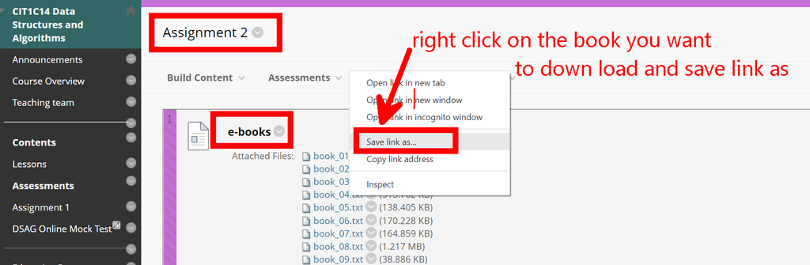

### 2. Download the file "stop_words_english.txt" from LMS. Go Assignment 2-->Stop words and right click -->save link as...

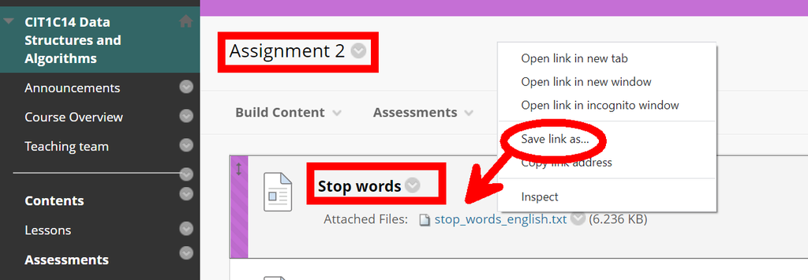

### 3. Create a dictionary to count the number of words in the book. Use the stop_words_english to remove any stop words found in the book. Remove all punctuations using the following punctuations variable.

punctuations = '''!()-[]{};:'"\,<>./?@#$%^&*_~“‘'''

### 4. Print the top 10 most frequent words in the book assigned to you by your register numbers.

### 5. To test your code, you may use the sample_run_book.txt in the LMS. Go to lms-->Assignment 2-->Book for sample run.

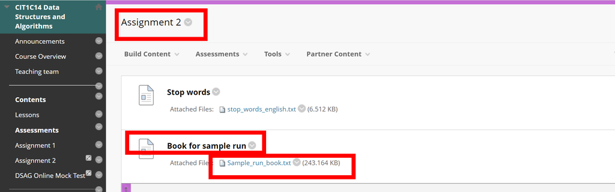

### Download the file and test it with your code. The expected output is as shown below.

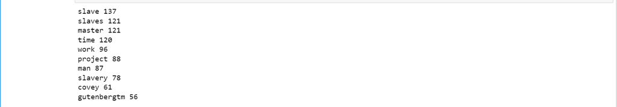

```python
punctuations = '''!()-[]{};:'"\,<>./?@#$%^&*_~“‘'''
def remove_punctuation(word):
    word_only = ""
    for ch in word:
        if ch not in punctuations:
            word_only += ch
    return (word_only)

#this function has a for loop which goes through each character and check if theres a punctuation
#if ch is not a punctuation in the list provided, it will add on to the string called words_only


stopwords = [] #empty list
with open("stop_words_english.txt", "r", encoding = "UTF-8") as my_stopwords:
    for word in my_stopwords:
        word = remove_punctuation(word) #remove all punctuations from stopwords using remove_punctuation
        word = word.rsplit() #splits a string into a list
        if word[0] not in stopwords:
            stopwords += word


bookwords = [] #empty list
with open("book_03.txt", "r", encoding = "utf-8-sig") as my_book:
    for line in my_book:
        line = line.rstrip("\n")
        line = line.rsplit()
        for word in line:
            word = remove_punctuation(word)
            word = word.lower()
            if  (word not in stopwords) and (word.isalpha() == True):
                bookwords.append(word)

#remove all punctuations and numbers from words
#isalpha() checks whether the string consists of alphabetic characters only
#we need to convert the words to all lowercase because if for example there are 2 of the same words - STOP and stop,
#python will process these 2 words as different although they are the same word
#this will affect our count for frequncy and it will no longer be accurate

bookwords_freq_dict = {} #empty dictionary
for word in bookwords:
    if word not in bookwords_freq_dict.keys():
        bookwords_freq_dict[word] = 1
    else:
        bookwords_freq_dict[word] += 1

#if the word is not in the dictionary, the key remains the same
#else if the word is already in the dictionary we increase the key by 1


bookwords_freq_list = []
for key, value in bookwords_freq_dict.items():
    bookwords_freq_list.append(value)
bookwords_freq_list.sort(reverse = True)

#we want to get the top 10 most frequent words
#sort() method sorts the list ascending by default

top_ten_freq = bookwords_freq_list[0:10]
top_ten_freq_unique = []
for freq in top_ten_freq:
    if freq not in top_ten_freq_unique:
        top_ten_freq_unique.append(freq)

#use slicing to get top 10 most frequenct words in a new list

bookwords_freq_dict_swapped = {}
for key, value in bookwords_freq_dict.items():
    if value not in bookwords_freq_dict_swapped:
        bookwords_freq_dict_swapped[value] = []
        bookwords_freq_dict_swapped[value].append(key)
    else:
        bookwords_freq_dict_swapped[value].append(key)

#we swap the key and value to get the output as word, followed by frequency value

for freq in top_ten_freq_unique:
    words_list = bookwords_freq_dict_swapped[freq]
    for word in words_list:
        print (word, freq)
```

```
elizabeth 588
darcy 349
bennet 279
jane 256
bingley 243
time 198
lady 181
good 178
sister 173
wickham 158
```

# Question 3 (10 marks)

### A computer programmer is to generate the following sequence of numbers:

### 2 5 9 19 37 . . .

### Write a recursive function to generate the first 10 numbers of the sequence.

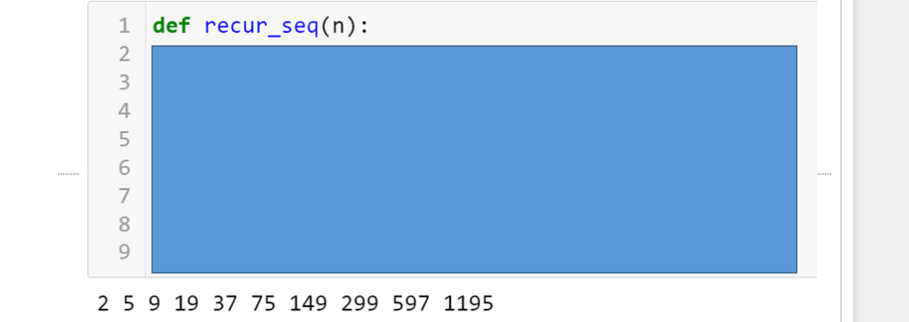

```python
def recur_seq(n):
    if n==1:
        return 2
#stopping/terminating condition

    elif n%2==0:
        return recur_seq(n-1)*2+1
#if n%2==0 it indicates the n is an even number because even numbers can divide by 2 without giving a remainder
    else:
        return recur_seq(n-1)*2-1
#if the previous condition is not met it shows that there is a remainder when n is divided by 2, proving that n is an odd number

#there is an alternating pattern between the number sequence hence 2 conditions are specified

#for example, (2)*2+1 = 5 where n=2(even number +1)
#where as, (5)*2-1 = 9 where n=3 (odd number +1)
#(n-1) refers to the previous term

for i in range(1, 11):
    print(recur_seq(i), end=' ')
#use a for loop to print the first 10 numbers of the sequence
#use end=' ' so that all the numbers will be printed in one row/line rather than in one column
```

```
2 5 9 19 37 75 149 299 597 1195
```

### The marking scheme for Assignment 2 is as shown below:

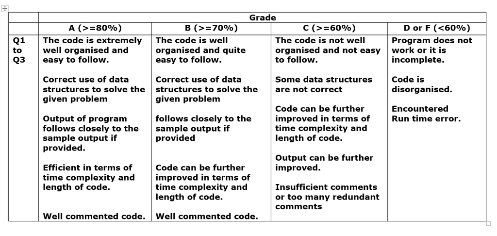